# Homework 4

Author

Anna Hiltner Nouzeilles

# Problem Set Part 1

# 1.

## a.

9 = 2 + 3*2 + ε

ε = 1

1 is the error, or the gap from the true model

## b.

9 = 1.9 + 3.1*2 = 0.9

0.9 is the residual, or the gap from the fitted line

# 2.

## top left

$Y = \beta_0 + \beta_1 X + \beta_2 D + \varepsilon$

or

Y ~ X + D

## top right

$Y = \beta_0 + \beta_1 X + \varepsilon$

or

Y ~ X

## bottom left

$Y = \beta_0 + \beta_1 X + \varepsilon$

or

Y ~ X

## bottom right

Not possible because we would need to include A in the regression but A is unobserved.

# 3.

## a.

76.185 hours

## b.

19.693

## c.

The intercept for model 3: 306.553

## d.

1256.671 - 2*238.853 = 778.965 hours

## e.

For the result to be statistically significant at the 95% level, we need t to be below -1.96 or above 1.96.

$$t = \frac{\hat{\beta}_1}{SE(\hat{\beta}_1)}$$

We use the t-statistic instead of the z-score because it is sample-based.

### Model 2:

-238.853 / 19.693 = -12.13

The coefficient is about 12.13 standard deviations away from zero.

### Model 3:

-251.181 / 19.28 = -13.03

The coefficient is about 13.03 standard deviations away from zero.

# 4.

$AnnualHoursWorked = \beta_0 + \beta_1 Edu + \beta_2 Edu^2$

## a.

A one-year increase in education is associated with a ( $\beta_1 + 2\beta_2 Edu$ )-unit change in annual hours worked. This is the marginal effect of education.

## b.

The marginal effect when education = 16 is 110.230 + 2*-1.581 * 16 = 59.638 hours per year. This is the slope of the regression curve at 16 years of education.

## c.

It is getting less positive because $\beta_2$ is less than zero.

## d.

Including a whole bunch of additional powers of education in this model could lead to overfitting that fits noise instead of a true relationship. This also makes it less generalizable.

# 5.

## a.

The coefficient 50.174 means homeowners work 50.174 more hours per one-year increase than non-homeowners. 50.174 / 32.923 = 1.52, which means it is not statistically significant at 95% because it is less than 1.96.

## b.

-923.904 - (-773.412) = -150.492.

People with 4 children under 5 work 150.492 less hours than those with 3 children under 5.

## c.

No because the table only gives each coefficient’s SE. We could test it by running a joint F-test or Wald test.

# 6.

## a.

Since the model has an interaction row, the slope of education depends on the homeowner row. For non-homeowners, the effect of education is 110.073 hours per year. For homeowners, the effect is 110.073-53.994=56.079 hours per year.

## b.

The Homeowner x Education coefficient is -53.994 which means that for every one-unit increase in education, homeowners work 53.994 hours less than non-homeowners.

## c.

In model 2, a one-year increase in education is associated with 100*(exp(0.067) - 1) = 6.93% more hours worked.

## d.

A 1% change in X corresponds with a 0.01 change in log(x). Therefore, a 1% change in education changes hours worked by 832.347*0.01 = 8.324 hours.

## e.

The sample size is smaller in model 2 because observations with zero hours worked cannot be logged and are dropped.

# 7.

(b) Autocorrelation occurs when error terms are correlated across time, such that knowing the error term in one period gives us some information about the error term in the next period.

# 8.

(b) and (e)

(a) is wrong because it looks at slope, not spread.

(c) is wrong because we should only use variables included in the model.

(d) is wrong because R^2 just looks at how well X explain Y rather than the errors.

# 9.

The pollster can use weighting to make their estimates reflect the proportions of the population. They would first need to calculate each group’s weight (population proportion / sample proportion) then apply the weights to the observations.

# 10.

A measurement error is classical if it is unrelated to the true value of the variable or other variables in the model. It is non-classical if it is correlated with the true value. (a) is the answer because the bias is systematic rather than random. (b) and (c) are classical measurement error.

# Problem Set Part 2

# 1.

```r
m1 <- lm(NoYes ~ humid + temp,
         data = d)

summary(m1)
```

```
Call:
lm(formula = NoYes ~ humid + temp, data = d)

Residuals:
    Min      1Q  Median      3Q     Max
-1.1055 -0.1442 -0.0062  0.1767  1.3624

Coefficients:
             Estimate Std. Error t value Pr(>|t|)
(Intercept) -0.407272   0.019033 -21.398   <2e-16 ***
humid        0.052851   0.001955  27.034   <2e-16 ***
temp        -0.003286   0.001778  -1.848   0.0648 .
---
Signif. codes:  0 '***' 0.001 '**' 0.01 '*' 0.05 '.' 0.1 ' ' 1

Residual standard error: 0.331 on 1995 degrees of freedom
  (2 observations deleted due to missingness)
Multiple R-squared:  0.5492,    Adjusted R-squared:  0.5488
F-statistic:  1215 on 2 and 1995 DF,  p-value: < 2.2e-16
```

# 2.

```r
m2 <- glm(NoYes ~ humid + temp,
         data = d,
         family = binomial(link = "logit"))

summary(m2)
```

```
Call:
glm(formula = NoYes ~ humid + temp, family = binomial(link = "logit"),
    data = d)

Deviance Residuals:
    Min       1Q   Median       3Q      Max
-2.7240  -0.3912  -0.2006   0.4830   3.5471

Coefficients:
            Estimate Std. Error z value Pr(>|z|)
(Intercept) -6.59219    0.30290 -21.764   <2e-16 ***
humid        0.30474    0.01985  15.350   <2e-16 ***
temp         0.03987    0.01933   2.063   0.0391 *
---
Signif. codes:  0 '***' 0.001 '**' 0.01 '*' 0.05 '.' 0.1 ' ' 1

(Dispersion parameter for binomial family taken to be 1)

    Null deviance: 2711.7  on 1997  degrees of freedom
Residual deviance: 1357.0  on 1995  degrees of freedom
  (2 observations deleted due to missingness)
AIC: 1363

Number of Fisher Scoring iterations: 6
```

```r
p_hat <- predict(m2, type = "response")
summary(p_hat)
```

```
   Min. 1st Qu.  Median    Mean 3rd Qu.    Max.
0.00111 0.04400 0.30893 0.41491 0.83407 0.97552
```

0.4149*(1-0.4149)=0.2429 is the predicted probability

0.30474*0.2429=0.0741

0.03987*0.2429=0.0097

A unit increase of humidity is associated with a log odds increase in dengue of 0.30474. It increases the probability of having dengue by 7.4 percentage points on average.

A unit increase of temperature is associated with a log odds increase in dengue of 0.03987. It increases the probability of having dengue by 1 percentage point on average.

# 3.

```r
d <- d |>
  drop_na(humid)

m3 <- lm(humid ~ temp,
         data = d)
summary(m3)
```

```
Call:
lm(formula = humid ~ temp, data = d)

Residuals:
     Min       1Q   Median       3Q      Max
-14.7416  -1.8751   0.4252   2.5564  13.9461

Coefficients:
            Estimate Std. Error t value Pr(>|t|)
(Intercept)  2.36152    0.21141   11.17   <2e-16 ***
temp         0.77885    0.01052   74.05   <2e-16 ***
---
Signif. codes:  0 '***' 0.001 '**' 0.01 '*' 0.05 '.' 0.1 ' ' 1

Residual standard error: 3.79 on 1996 degrees of freedom
Multiple R-squared:  0.7331,    Adjusted R-squared:  0.733
F-statistic:  5483 on 1 and 1996 DF,  p-value: < 2.2e-16
```

```r
d <- d |>
  mutate(res = m3$residuals)
```

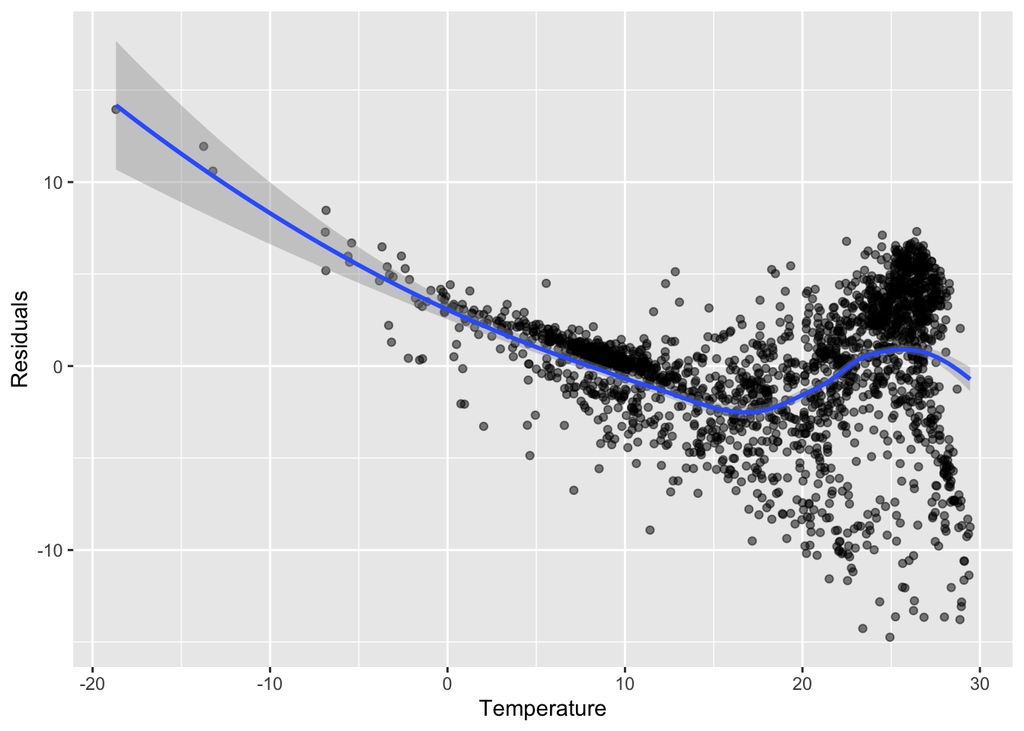

There is likely heteroskedasticity because the variance of the residuals increases as temperature increases.

```r
m4 <- feols(humid ~ temp,
            data = d,
            se = "hetero")
summary(m4)
```

```
OLS estimation, Dep. Var.: humid
Observations: 1,998
Standard-errors: Heteroskedasticity-robust
            Estimate Std. Error t value  Pr(>|t|)
(Intercept) 2.361523   0.195914 12.0539 < 2.2e-16 ***
temp        0.778849   0.011529 67.5563 < 2.2e-16 ***
---
Signif. codes:  0 '***' 0.001 '**' 0.01 '*' 0.05 '.' 0.1 ' ' 1
RMSE: 3.78837   Adj. R2: 0.732993
```

```r
summary(m3)
```

```
Call:
lm(formula = humid ~ temp, data = d)

Residuals:
     Min       1Q   Median       3Q      Max
-14.7416  -1.8751   0.4252   2.5564  13.9461

Coefficients:
            Estimate Std. Error t value Pr(>|t|)
(Intercept)  2.36152    0.21141   11.17   <2e-16 ***
temp         0.77885    0.01052   74.05   <2e-16 ***
---
Signif. codes:  0 '***' 0.001 '**' 0.01 '*' 0.05 '.' 0.1 ' ' 1

Residual standard error: 3.79 on 1996 degrees of freedom
Multiple R-squared:  0.7331,    Adjusted R-squared:  0.733
F-statistic:  5483 on 1 and 1996 DF,  p-value: < 2.2e-16
```

The standard error on temperature in model 4 is slightly higher than the one in model 3. Even though the difference is not large, it is consistent with heteroskedasticity.

# 4.

```r
m5 <- feols(log(humid) ~ temp,
            data = d,
            se = "hetero")
summary(m5)
```

```
OLS estimation, Dep. Var.: log(humid)
Observations: 1,998
Standard-errors: Heteroskedasticity-robust
            Estimate Std. Error t value  Pr(>|t|)
(Intercept) 1.659049   0.018220 91.0589 < 2.2e-16 ***
temp        0.056482   0.000886 63.7548 < 2.2e-16 ***
---
Signif. codes:  0 '***' 0.001 '**' 0.01 '*' 0.05 '.' 0.1 ' ' 1
RMSE: 0.248727   Adj. R2: 0.770082
```

(exp(0.056482)-1)*100= 5.811

A one-unit increase in temperature is associated with a 5.811% increase in humidity.

# 5.

The plot looks more curved than linear and the variance of residuals got larger at higher temperatures. Taking the log of humidity makes it more linear and reduces variance.